# NCAA Volleyball Expected Points and WAR Model

A Rally Level Value Framework for Player Evaluation

## Executive Summary

Traditional volleyball box-score statistics typically record a team’s and player’s kills, digs, assists, points scored, and other metrics during a game. However, these numbers often fail to account for a player’s specific role on the court or the actual game context in which points are scored. This makes it difficult to truly measure how much a player contributes to their team’s victories.

Therefore, we created this project with the goal of more accurately evaluating each player’s contribution to their team during actual matches, starting from data collected per rally and incorporating positional adjustment values. With data collected from the 2024 NCAA Division I Women’s Volleyball season we developed an Expected Points (EP) model used to estimate the probability that each offensive play will result in the team winning the rally and scoring a point. Building upon this foundation, we further developed a Wins Above Replacement (WAR) model to quantify the performance value of players across different positions.

We combined five data sets from the women’s 2024 season (play-by-play, player match, player season, team match, and team season) to structure a single data set where each row represented a single rally where a point was scored. Using our rally level data we fitted a logistic regression model to estimate Expected Points (EP) or the probability that the home team scored the next point, based on the score differential, set number, and event type. Each rally’s Expected Points Added (EPA) was defined by the difference in the predicted probabilities of the home team scoring before and after each rally. We aggregated EPA by player and adjusted for position specific replacement levels, which we defined as players within the bottom 20% of EPA values within each position, to produce a Wins Above Replacement (WAR) metric, that quantified how many points a player added above a typical replacement level player.

Overall, this analytical framework moves us beyond surface level box-score statistics. By integrating positional roles, it enables a more comprehensive and game realistic assessment of each player’s contribution by position group.

## Model Overview

Utilizing detailed play-by-play data from the `ncaavolleyballr` package on GitHub, we developed the Expected Points (EP) model and WAR-like metrics to evaluate individual contributions.

Inspired by similar analytical approaches in other sports, such as expected goals in soccer and ice hockey, our methodology adapts to volleyball’s unique rotation structure, where each action (serve, attack, block, or error) can instantly alter the probability of winning the next point.

This report details the methodology behind our NCAA volleyball player expected scoring model, demonstrates its ability to measure player and positional impact, and highlights its utility in identifying the most influential players on the court.

## Data Sourcing & Data Pipelines

We utilized data from the 2024 NCAA Division 1 women’s volleyball season available from the `ncaavolleyballr` repository.

- `wvb_pbp_div1_2024.csv` – play-by-play event data
- `wvb_playermatch_div1_2024.csv` – per match player statistics
- `wvb_playerseason_div1_2024.csv` – cumulative season player statistics
- `wvb_teammatch_div1_2024.csv` – per match team statistics
- `wvb_teamseason_div1_2024.csv` – season level team statistics

**Expand to view data ingestion scripts**

```r
url1<- "https://media.githubusercontent.com/media/JeffreyRStevens/ncaavolleyballr/refs/heads/main/data-csv/wvb_teamseason_div1_2024.csv"
teamseason <- read_csv(url1)

url2 <- "https://media.githubusercontent.com/media/JeffreyRStevens/ncaavolleyballr/refs/heads/main/data-csv/wvb_pbp_div1_2024.csv"
pbp <- read_csv(url2)

url3 <- "https://media.githubusercontent.com/media/JeffreyRStevens/ncaavolleyballr/refs/heads/main/data-csv/wvb_playermatch_div1_2024.csv"
playermatch <- read_csv(url3)

url4 <-"https://media.githubusercontent.com/media/JeffreyRStevens/ncaavolleyballr/refs/heads/main/data-csv/wvb_playerseason_div1_2024.csv"
playerseason <- read_csv(url4)

url5 <- "https://media.githubusercontent.com/media/JeffreyRStevens/ncaavolleyballr/refs/heads/main/data-csv/wvb_teammatch_div1_2024.csv"
teammatch <- read_csv(url5)
```

To transform the raw play-by-play events into a structured dataset ready for machine learning, we built functionalized cleaning pipelines to standardize features and calculate active point differentials.

**Expand to view data cleaning pipeline functions**

```r
# create function to clean names
clean_names_safe <- function(df){
  out <- df
  names(out) <- names(out) |>
    str_trim() |>
    str_replace_all("\\s+", "_") |>
    str_replace_all("[()/]", "_") |>
    tolower()
  as_tibble(out, .name_repair = "unique")}

process_volleyball_data <- function(pbp_raw, teammatch_raw, playermatch_raw) {
  # clean column names
  pbp_c          <- clean_names_safe(pbp_raw)
  teammatch_c    <- clean_names_safe(teammatch_raw)
  playermatch_c  <- clean_names_safe(playermatch_raw)

  # parse dates safely
  pbp_c <- pbp_c %>% mutate(date = mdy(as.character(date)))

  teammatch_c <- teammatch_c %>%
    mutate(date_parsed = mdy(as.character(date)),
           date_clean = str_remove_all(date, "\\s*\\(\\d+\\)"),
           date_parsed = coalesce(date_parsed, mdy(date_clean))) %>%
    select(-date_clean)

  playermatch_c <- playermatch_c %>%
    mutate(date_parsed = coalesce(as.Date(date), ymd(as.character(date))))

  # structural score engineering
  pbp_c <- pbp_c %>%
    mutate(score = str_trim(score)) %>%
    tidyr::separate(score,
                    into = c("home_score_chr", "away_score_chr"),
                    sep = "-",
                    fill = "right",
                    remove = FALSE) %>%
    mutate(
      home_score = suppressWarnings(as.integer(home_score_chr)),
      away_score = suppressWarnings(as.integer(away_score_chr)),
      date_key = if (inherits(date, "Date")) date else suppressWarnings(mdy(as.character(date))),
      date_clean = if_else(is.na(date_key), str_remove_all(as.character(date), "\\s*\\(\\d+\\)"), as.character(date)),
      date_key = coalesce(date_key, mdy(date_clean)),
      match_key = paste(format(date_key, "%Y-%m-%d"), home_team, "vs", away_team, sep = "_"),
      invalid_score = if_else(!str_detect(score, "^\\d+-\\d+$"), TRUE, FALSE)) %>%
    select(-home_score_chr, -away_score_chr, -date_clean)

  pbp_c_score <- pbp_c %>%
    dplyr::filter(!invalid_score) %>%
    mutate(home_score = as.integer(str_extract(score, "^\\d+")),
           away_score = as.integer(str_extract(score, "(?<=-)\\d+")))

  # sequence point indices
  pbp_c_score <- pbp_c_score %>%
    group_by(match_key, set) %>%
    mutate(score_pair = paste0(home_score, "-", away_score),
           score_pair_prev = lag(score_pair),
           point_change = score_pair != score_pair_prev,
           point_id = cumsum(replace_na(point_change, TRUE))) %>%
    ungroup()

  # isolate actual scoring boundary shifts
  pbp_points <- pbp_c_score %>%
    filter(!is.na(match_key)) %>%
    arrange(match_key, set, date_key) %>%
    group_by(match_key, set) %>%
    mutate(home_delta = home_score - lag(home_score),
           away_delta = away_score - lag(away_score),
           point_scored_row = (home_delta == 1 & (away_delta %in% c(0, NA))) |
             (away_delta == 1 & (home_delta %in% c(0, NA)))) %>%
    ungroup()

  pbp_points_scored <- pbp_points %>% filter(point_scored_row,
                                             !is.na(match_key))
  return(pbp_points_scored)}

# run the ingestion pipeline
pbp_points_scored <- process_volleyball_data(pbp, teammatch, playermatch)
```

Each row in the prepared dataset corresponds with the end of a rally, where one team won the rally and their score increased by exactly 1. Below is a snapshot of the structured sequence data:

| match_key | set | team | event | home_score | away_score | player | description |
| --- | --- | --- | --- | --- | --- | --- | --- |
| 2024-08-27_Kentucky_vs_Nebraska | 1 | Kentucky | First ball kill | 0 | 1 | Jordyn Dailey | First ball kill by Jordyn Dailey |
| 2024-08-27_Kentucky_vs_Nebraska | 1 | Nebraska | First ball kill | 1 | 1 | Merritt Beason | First ball kill by Merritt Beason |
| 2024-08-27_Kentucky_vs_Nebraska | 1 | Nebraska | Kill | 2 | 1 | Rebekah Allick | Kill by Rebekah Allick |
| 2024-08-27_Kentucky_vs_Nebraska | 1 | Nebraska | Block | 3 | 1 | Merritt Beason, Rebekah Allick | Block by Merritt Beason, Rebekah Allick |
| 2024-08-27_Kentucky_vs_Nebraska | 1 | Kentucky | First ball kill | 3 | 2 | Brooklyn DeLeye | First ball kill by Brooklyn DeLeye |

## Expected Points (EP) Model

To further transform the point-level data to prepare for the Expected Points model, we added variables relevant for modeling. We formulated a binary indicator, `scoring_team_is_home`, to denote whether the home team scored the point. The context immediately prior to the play is captured via `score_diff_before`.

To regularize raw structural variation, we collapsed text variations in the `event` variable into consolidated strategic categories: **Kill, Error, Block, Ace, Serve, and Other**.

**Expand to view variable transformations**

```r
pbp_model <- pbp_points_scored %>%
  mutate(
    #binary variable for if home or away team won rally
    scoring_team_is_home = if_else(team == home_team, 1, 0),
    #calculate score margin prior to current play
    score_diff_before = home_score - away_score - scoring_team_is_home,
    #convert set number into categorical factor
    set_factor = factor(set),
    #consolidate event strings into standardized categories
    event_simplified = case_when(
      str_detect(tolower(event), "kill") ~ "Kill",
      str_detect(tolower(event), "block") ~ "Block",
      str_detect(tolower(event), "error") ~ "Error",
      str_detect(tolower(event), "ace") ~ "Ace",
      str_detect(tolower(event), "serve") ~ "Serve",
      TRUE ~ "Other"),
    event_simplified = factor(event_simplified)) %>%
  #keep only necessary modeling features
  select(match_key, set_factor, event, event_simplified, home_score,
         away_score, score_diff_before, scoring_team_is_home)
```

`pbp_model` is a simplified and cleaned version of the play-by-play data that includes only the variables needed to fit our Expected Points (EP) model, with one row per rally and all information required to predict whether the home team will score the next point.

To build our baseline EP model, we fit a generalized linear model (GLM) using the `speedglm` package on a representative sample of matches to forecast the likelihood that the home team scores the next rally given the active context.

The GLM predicted `scoring_team_is_home` modeled on three key predictors:

- `score_diff_before`: home score - away score before the rally
- `set_factor`: categorical indicator for set number (1-5)
- `event_simplified`: simplified rally ending events (kill, block, error, serve, ace, or other

**Expand to view GLM fitting**

```r
#set seed for reproducible results
set.seed(123)

#randomly sample 100,000 for memory/performance efficiency
idx <- sample.int(nrow(pbp_model), size = min(100000, nrow(pbp_model)))
pbp_small <- pbp_model[idx, , drop = FALSE]

#fit binomial logistic regression expected points model
ep_model_clean <- speedglm::speedglm(
  scoring_team_is_home ~ score_diff_before + set_factor + event_simplified,
  data = pbp_small,
  family = binomial())

#output regression coefficients and p-values
summary(ep_model_clean)
```

```
Generalized Linear Model of class 'speedglm':

Call:  speedglm::speedglm(formula = scoring_team_is_home ~ score_diff_before +      set_factor + event_simplified, data = pbp_small, family = binomial())

Coefficients:
 ------------------------------------------------------------------
                        Estimate Std. Error    z value  Pr(>|z|)
(Intercept)           -0.0746280   0.028522   -2.61650 0.0088836 **
score_diff_before     -0.1903950   0.001825 -104.34996 0.0000000 ***
set_factor2            0.0174973   0.018342    0.95397 0.3400965
set_factor3            0.0005521   0.018310    0.03015 0.9759475
set_factor4            0.0281733   0.021918    1.28541 0.1986489
set_factor5            0.0720087   0.038682    1.86157 0.0626638 .
event_simplifiedBlock -0.0494959   0.033277   -1.48737 0.1369169
event_simplifiedError -0.1073310   0.029397   -3.65107 0.0002612 ***
event_simplifiedKill  -0.0479661   0.027773   -1.72706 0.0841567 .
event_simplifiedOther -0.0302405   0.217706   -0.13891 0.8895249
event_simplifiedServe -0.3902541   0.458794   -0.85061 0.3949873

-------------------------------------------------------------------
Signif. codes:  0 '***' 0.001 '**' 0.01 '*' 0.05 '.' 0.1 ' ' 1

---
null df: 99999; null deviance: 138569.6;
residuals df: 99989; residuals deviance: 124921.1;
# obs.: 100000; # non-zero weighted obs.: 100000;
AIC: 124943.1; log Likelihood: -62460.57;
RSS: 101761.3; dispersion: 1; iterations: 4;
rank: 11; max tolerance: 2.73e-13; convergence: TRUE.
```

This model predicts the probability that the home team scores in the next rally, which we then used to produce Expected Points (EP) values and assign each rally an EP value between 0 and 1, predicting whether or not the home team will score the next point.

**Expand to view prediction generation**

```r
#generate out of sample expected point probabilities for all rallies
pbp_ep <- pbp_model %>%
  mutate(ep_home = predict(ep_model_clean,
                           newdata = pbp_model,
                           type = "response"))
```

EP values close to 1 indicate the home team is expected to score the next point, whereas EP values close to 0 signify the away team has a high likelihood to score, and EP values around 0.5 reflect both teams having a roughly even chance of scoring.

| mean_ep | min_ep | max_ep |
| --- | --- | --- |
| 0.5116882 | 0.0159709 | 0.9860261 |

The average predicted EP is 0.512, showing rallies are very balanced, and the range of EP values between 0.016 and 0.986 shows the model’s ability to detect rallies where one side is almost certain to score.

## Expected Points Added (EPA) per rally

By linking the Expected Points values to individual players, we derive **Expected Points Added (EPA)** for every rally:

$$\text{EPA} = \text{EP}_{\text{after\_rally}} - \text{EP}_{\text{before\_rally}}$$

This measures how much a player’s action (like a kill, ace, or error) changes the team’s probability of scoring.

**Expand to view EPA formulation**

```r
#derive point by point EPA (delta in expected points before and after play)
pbp_ep <- pbp_ep %>%
  group_by(match_key, set_factor) %>%
  arrange(home_score + away_score, .by_group = TRUE) %>%
  mutate(point_index = home_score + away_score,
         ep_before = lag(ep_home),
         epa = ep_home - ep_before) %>%
  ungroup()

#clean player season dataset
playerseason_c <- clean_names_safe(playerseason)

#map plays to players with event records
rallies_with_keys <- pbp_points_scored %>%
  dplyr::filter(point_scored_row, !is.na(match_key)) %>%
  dplyr::mutate(set_factor = factor(set)) %>%
  dplyr::group_by(match_key, set_factor) %>%
  dplyr::arrange(home_score + away_score, .by_group = TRUE) %>%
  dplyr::mutate(point_index = home_score + away_score) %>%
  dplyr::ungroup() %>%
  dplyr::select(match_key, set_factor, point_index, team, player, event)

#join rally EPA metrics with specific player events
epa_with_players <- pbp_ep %>%
  dplyr::filter(!is.na(epa)) %>%
  dplyr::select(match_key, set_factor, point_index, epa) %>%
  dplyr::inner_join(rallies_with_keys, by = c("match_key", "set_factor", "point_index"))

#aggregate play by play EPA at the player-team level
player_epa <- epa_with_players %>%
  dplyr::filter(!is.na(player), player != "") %>%
  dplyr::group_by(player, team) %>%
  dplyr::summarise(
    points_tagged = dplyr::n(),
    total_epa = sum(epa, na.rm = TRUE),
    mean_epa  = mean(epa, na.rm = TRUE),
    .groups = "drop")

#strip player strings
player_epa_clean <- player_epa %>%
  mutate(player_clean = str_squish(str_remove(player, "\\s*\\(.*\\)$")))

#map primary player positions
pos_map <- playerseason %>%
  rename(pos = Pos, player_raw = Player, team_raw = Team) %>%
  mutate(player_clean = str_squish(str_remove(player_raw, "\\s*\\(.*\\)$"))) %>%
  filter(!is.na(pos), pos != "") %>%
  count(player_clean, team_raw, pos, name = "n") %>%
  group_by(player_clean, team_raw) %>%
  slice_max(n, n = 1, with_ties = FALSE) %>%
  ungroup() %>%
  transmute(player_clean, team_raw, pos)

#combine player EPA data with primary season position mapping
player_epa_pos <- player_epa_clean %>%
  left_join(pos_map, by = c("player_clean" = "player_clean", "team" = "team_raw"))

#create secondary fallback position map from player match records
pos_map_pm <- playermatch %>%
  dplyr::rename(pos_raw = P, player_raw = Player, team_raw = Team) %>%
  dplyr::filter(!is.na(pos_raw), pos_raw != "") %>%
  dplyr::mutate(player_clean = stringr::str_squish(stringr::str_remove(player_raw, "\\s*\\(.*\\)$"))) %>%
  dplyr::count(player_clean, pos_raw, name = "n") %>%
  dplyr::group_by(player_clean) %>%
  dplyr::slice_max(n, n = 1, with_ties = FALSE) %>%
  dplyr::ungroup()

#function to harmonize raw position strings into standard positional groups
standardize_pos <- function(x) {
  x <- toupper(trimws(x))
  dplyr::case_when(
    x %in% c("OH") ~ "OH",
    x %in% c("RS","OPP","RIGHT","RSH") ~ "OPP",
    x %in% c("MB","MH","MIDDLE") ~ "MB",
    x %in% c("S","SETTER") ~ "S",
    x %in% c("L","L/DS","DS","LIBERO") ~ "L/DS",
    TRUE ~ NA_character_)}

#standardize match level fallback positions
pos_map_pm <- pos_map_pm %>%
  dplyr::mutate(pos_pm = standardize_pos(pos_raw)) %>%
  dplyr::select(player_clean, pos_pm)

#input missing primary positions using match level secondary map
player_epa_pos2 <- player_epa_pos %>%
  dplyr::left_join(pos_map_pm, by = "player_clean") %>%
  dplyr::mutate(pos_final = dplyr::coalesce(pos, pos_pm)) %>%
  dplyr::select(player, team, points_tagged, total_epa, mean_epa, pos_final)

#final clean consolidation of position labels
player_epa_pos3 <- player_epa_pos2 %>%
  mutate(pos_final = toupper(trimws(pos_final))) %>%
  mutate(pos_final = case_when(
    pos_final %in% c("DS", "L", "MH") ~ "L/DS",
    pos_final %in% c("RS") ~ "OPP",
    pos_final %in% c("MH") ~ "MB",
    TRUE ~ pos_final))
```

Sorting by `total_epa` allows ranking the most influential players based on their contribution to expected scoring changes.

| Player | Team | Touches Tagged | Total EPA | Mean EPA |
| --- | --- | --- | --- | --- |
| Elise McGhee | Baylor | 430 | 12.771 | 0.030 |
| Kerry Keefe | Duke | 423 | 12.499 | 0.030 |
| Olivia Babcock | Pittsburgh | 572 | 12.359 | 0.022 |
| Riley Whitesides (from Sarah Jordan). | South Carolina | 166 | 12.159 | 0.073 |
| Harper Murray | Nebraska | 438 | 12.128 | 0.028 |
| Claire Little | BYU | 430 | 11.896 | 0.028 |
| Kaylee Cox | Western Ky. | 510 | 11.436 | 0.022 |
| Victoria Barrett | Towson | 492 | 11.351 | 0.023 |
| Aubrey Lapour | Bryant | 308 | 11.110 | 0.036 |
| Melanie Parra | TCU | 610 | 10.270 | 0.017 |
| Jaelyn Hodge | Arizona | 444 | 10.159 | 0.023 |
| Ema Uskokovic | UTEP | 394 | 9.928 | 0.025 |
| Brooklyn DeLeye | Kentucky | 558 | 9.737 | 0.017 |
| Silan Demirkol | Bradley | 347 | 9.714 | 0.028 |
| Jill Pressly | DePaul | 537 | 9.703 | 0.018 |

We now have per-player workload (`points_tagged`) and impact (`total_epa`, `mean_epa`) with corresponding positional categories. From this we will define replacement level players in order to compute position adjusted WAR.

## Wins Above Replacement (WAR)

To build a reliable baseline framework, we filtered out low-sample observations to retain players with a sufficient sample size of game data ($\ge 150$ tagged points).

A position-specific replacement baseline ($20^{\text{th}}$ percentile of execution) was computed to act as our structural evaluation threshold. Defining the replacement level provides a reference framework for evaluating individual player impact, quantifying their performance relative to the typical benchmark level at their position.

**Expand to view WAR framework**

```r
#filter dataset for high volume players
player_core <- player_epa_pos3 %>%
  dplyr::filter(!is.na(pos_final), points_tagged >= 150)

#calculate bottom 20th percentile replacement benchmark by position group
repl_by_pos <- player_core %>%
  dplyr::group_by(pos_final) %>%
  dplyr::summarise(
    #20th percentile threshold cutoff
    threshold = quantile(mean_epa, probs = 0.20, na.rm = TRUE),
    #average performance of players at or below replacement threshold
    repl_mean_epa = mean(mean_epa[mean_epa <= threshold], na.rm = TRUE),
    n_players = dplyr::n(),
    .groups = "drop")

#display calculated replacement values per position
repl_by_pos %>% knitr::kable(digits = 4)
```

| pos_final | threshold | repl_mean_epa | n_players |
| --- | --- | --- | --- |
| L/DS | -0.0068 | -0.0105 | 31 |
| MB | -0.0038 | -0.0100 | 376 |
| OH | -0.0054 | -0.0125 | 790 |
| OPP | -0.0059 | -0.0128 | 158 |
| S | -0.0064 | -0.0136 | 30 |

We then computed a Value Above Replacement (VAR), quantifying how much a player exceeds typical performance at their position. To scale this individual efficiency over the replacement baseline to calculate a seasonal volume adjusted metric for each player:

$$\text{WAR} = (\text{Mean EPA} - \text{Replacement Mean EPA}) \times \text{Points Tagged}$$

**Expand to view scaled WAR calculation**

```r
player_war <- player_core %>%
  #join position specific replacement threshold
  dplyr::left_join(repl_by_pos, by = "pos_final") %>%
  dplyr::mutate(
    #efficiency differential relative to position replacement baseline
    var_epa = mean_epa - repl_mean_epa,
    #volume adjusted WAR metric (value above replacement * total touches)
    war_like = var_epa * points_tagged
  ) %>%
  dplyr::arrange(dplyr::desc(war_like))
```

## Diagnostic Insights & Positional Analysis

### Overall Leaderboard

Explore the interactive table below to see the season’s top-performing players by individual WAR values.

|  | Player | Team | Position | Touches | Mean EPA | WAR |
| --- | --- | --- | --- | --- | --- | --- |
| 1 | Olivia Babcock | Pittsburgh | OPP | 572 | 0.02160732456439866 | 19.67714079135565 |
| 2 | Elise McGhee | Baylor | OPP | 430 | 0.02970026989351749 | 18.27222268082692 |
| 3 | Melanie Parra | TCU | OH | 610 | 0.01683673136103992 | 17.90810537557541 |
| 4 | Kaylee Cox | Western Ky. | OH | 510 | 0.02242437435867855 | 17.82204832476858 |
| 5 | Kerry Keefe | Duke | OH | 423 | 0.02954941540615228 | 17.79570891480121 |
| 6 | Harper Murray | Nebraska | OH | 438 | 0.02769025374475597 | 17.6124496147267 |
| 7 | Victoria Barrett | Towson | OH | 492 | 0.02307207561888675 | 17.51170387450507 |
| 8 | Claire Little | BYU | OH | 430 | 0.02766537198899998 | 17.28006188231369 |
| 9 | Brooklyn DeLeye | Kentucky | OH | 558 | 0.01744936612154844 | 16.72336298254585 |
| 10 | Malaya Jones | Colorado St. | OH | 550 | 0.01736341467075038 | 16.43632820815465 |

[output cut: 1375 more lines]

### Top 10 Standouts by Position Group

The plot below breaks down efficiency gains across individual tactical domains, illustrating which players create the largest output variations.

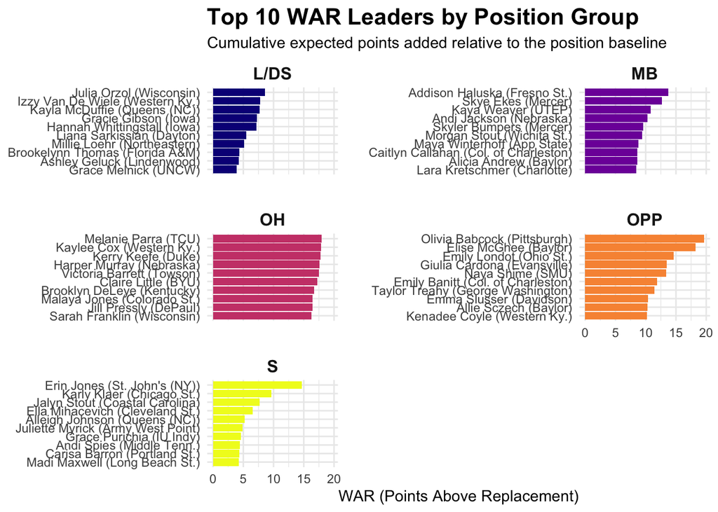

Positional insights:

- Opposite (OPP) and outside (OH) hitters: largest WAR increases per EPA gain
- Setters (S): steady WAR despite smaller EPA range
- Liberos and Defense Specialists (L/DS): low variance, defensive stability

### Volumetric Scaling: Efficiency vs. WAR Value

Analyzing the interaction between efficiency and volume reveals how roles scale across different positions on the court.

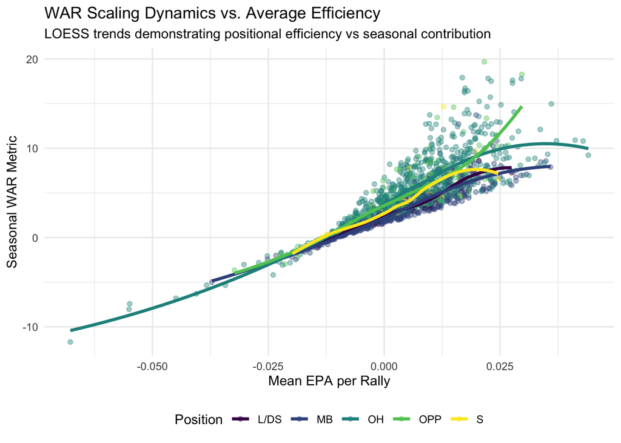

The scatter plot highlights the interplay between workload and efficiency: players with higher average EPA but fewer plays may have lower WAR-like values, while those with consistent EPA and heavier workloads accumulate greater WAR-like contributions. The LOESS trendlines for each position reveal typical contribution patterns across roles, helping identify which positions yield higher WAR-like values for a given average EPA and we can see clear differences between position groups.

- **Outside Hitters (OH):** Covers the broadest spectrum of efficiency, illustrating high volatility and variance in seasonal impact.
- **Opposites (OPP):** Displays the steepest curve slope, showing that marginal gains in offensive efficiency yield major returns in cumulative team wins.
- **Setters & Defensive Specialists (L/DS):** Exhibit compressed horizontal efficiency clusters, highlighting highly consistent and dependable support play.

## Limitations and Future Work

Several practical and methodological limitations of our analysis should be noted.

First, the play-by-play dataset was extremely large (over 5.6 million rows), which exceeded the feasible memory and runtime for a full logistic regression in R. To address this, we estimated the expected points model using the speedglm package on a random sample of 100,000 rallies, which provides computational efficiency but may slightly increase variance in coefficient estimates compared to fitting on the full dataset.

Second, data cleaning required excluding a small portion of problematic records. Approximately 6,500 rallies had invalid or unparseable score strings (e.g., duplicated entries or malformed text such as “Air Force subs…”). These were filtered out because they could not reliably indicate a scoring outcome.

Third, player position data were incomplete. The position field (pos_final) contained a significant number of missing values, especially for less frequently recorded players or schools with inconsistent reporting. To ensure consistency in position based WAR comparisons, we restricted the replacement-level calculations and position visualizations to players with a known position, effectively excluding those with NA positions. This exclusion slightly reduced the total sample size but avoided biased or misclassified positional averages.

Finally, this analysis did not model contextual or temporal dependencies such as rotation order, serve-receive quality, or opponent strength. The current model assumes rally independence and equal competitive balance across teams, which is an approximation. Additionally, replacement level thresholds and WAR-like scaling were arbitrarily determined, meaning the exact magnitudes of value are approximate even if the relative rankings are informative.

Despite these limitations, the we established a foundation for rally level value modeling in volleyball. In the future, additional computing resources and incorporating other models to account for non linear patterns would allow for more precise analysis. Additional analysis that adjusts for opponent quality and rotational tracking and context would also improve precision and realism. This framework can also be extended to team-level win probability and cross-season validation to produce additional insights.

## References

Stevens, Jeffrey R. 2023. “ncaavolleyballr: NCAA Women’s Volleyball Play-by-Play Data.” https://jeffreyrstevens.github.io/ncaavolleyballr/articles/data.html